# Experiment 2 notebook (Lab version)

Jake Vincent

# Background

Experiment 2 is a follow-up experiment to [Experiment 1](https://people.ucsc.edu/~jwvincen/experiment1.html). Experiment 1 Used a length × complexity design (following Sprouse, Wagers, and Phillips (2013)), and included as a factor the definiteness of the DP containing a Complex NP island. No effect of definiteness on island transparency was found, so Experiment 2 follows up on Experiment 1 by asking whether the position and (existential) presuppositionality of the DP containing the island matters.

## Factors

The design of Experiment 2 differs from Experiment 1 by using a different kind of linguistic dependency in the baseline conditions, allowing the complexity factor to remain constant across all conditions. Instead of varying on the length of the same type of dependency (short extraction from subject position vs. long extraction from embedded object position, as in Experiment 1), Experiment 2 varies the type of dependency that occurs between an element in the clause-initial region and an element in the island region. This factor was called **dependency type**, and has two levels: *movement* and *anaphoric*.

The other factor collapses the definiteness, presuppositionality, and position of the island into which the dependency is constructed, but is called the **intermediate subject** factor, since the collapsed collection properties just mentioned is related to the identity of the intermediate subject. The levels of this factor are *there*, *indefinite*, and *definite*. The *there* conditions are arguably the most important, since definiteness was not found to have an impact in Experiment 1. The *there* conditions have the expletive DP *there* as the intermediate subject of an existential clause. In these clauses, the dependency was constructed into (what is arguably) the pivot of the existential, which is not a subject, but is in some lower position. The list of conditions are given in (1), and a parallel sample item set is given in (2).

1. **Conditions**
   1. THERE, MOVEMENT
   2. THERE, ANAPHORIC
   3. INDEFINITE, MOVEMENT
   4. INDEFINITE, ANAPHORIC
   5. DEFINITE, MOVEMENT
   6. DEFINITE, ANAPHORIC
2. **Sample item set**
   1. The president is someone that **there** are many Americans who supported _ in the election living in rural areas.
   2. The president thinks that **there** are many Americans who supported him in the election living in rural areas.
   3. The president is someone that **many Americans** who supported _ in the election are living in rural areas.
   4. The president thinks that **many Americans** who supported him in the election are living in rural areas.
   5. The president is someone that **the Americans** who supported _ in the election are living in rural areas.
   6. The president thinks that **the Americans** who supported him in the election are living in rural areas.

## Procedure

The experiment was administered using IBEX. 24 item sets were distributed into 6 lists automatically generated using IBEX’s automatic latin square generator. 64 fillers were used that were on average slightly shorter in length than the average length of the experimental items. Within each list, the experimental and filler items were randomly sorted. Participants were UC Santa Cruz undergraduates.

# Data summary and visualization

## By subject

| subject | expectedGramm | mean_rt_secs | mean_rating | sd_rating | n | se_rating |
| --- | --- | --- | --- | --- | --- | --- |
| 100 | 0 | 9.190319 | 2.531915 | 1.2996833 | 47 | 0.1895783 |
| 100 | 1 | 9.139156 | 4.111111 | 1.3688453 | 45 | 0.2040554 |
| 101 | 0 | 7.482021 | 2.574468 | 1.7162229 | 47 | 0.2503368 |
| 101 | 1 | 7.511889 | 4.955556 | 1.4609392 | 45 | 0.2177840 |
| 102 | 0 | 6.601915 | 2.489362 | 1.5017720 | 47 | 0.2190560 |
| 102 | 1 | 8.323867 | 3.933333 | 1.3551250 | 45 | 0.2020101 |
| 103 | 0 | 12.063957 | 2.765957 | 1.4327348 | 47 | 0.2089858 |
| 103 | 1 | 10.323533 | 4.555556 | 1.2164695 | 45 | 0.1813406 |
| 105 | 0 | 12.537723 | 3.255319 | 1.6999755 | 47 | 0.2479669 |
| 105 | 1 | 10.251778 | 5.222222 | 1.1655839 | 45 | 0.1737550 |

[output cut: 64 more lines]

## By item set

| itemSet | mean_rt_secs | mean_rating | sd_rating | n | se_rating |
| --- | --- | --- | --- | --- | --- |
| 1 | 10.049778 | 3.333333 | 1.906925 | 45 | 0.2842676 |
| 2 | 10.990600 | 3.000000 | 1.977142 | 45 | 0.2947349 |
| 3 | 9.530556 | 3.155556 | 1.678142 | 45 | 0.2501627 |
| 4 | 9.507378 | 3.222222 | 1.769552 | 45 | 0.2637892 |
| 5 | 11.427622 | 3.155556 | 1.821033 | 45 | 0.2714636 |
| 6 | 14.277889 | 2.888889 | 1.626796 | 45 | 0.2425084 |
| 7 | 11.682800 | 3.288889 | 1.618392 | 45 | 0.2412556 |
| 8 | 13.448378 | 3.422222 | 1.588151 | 45 | 0.2367475 |
| 9 | 8.642933 | 3.511111 | 1.740196 | 45 | 0.2594131 |
| 10 | 10.148444 | 3.488889 | 1.926162 | 45 | 0.2871353 |

[output cut: 14 more lines]

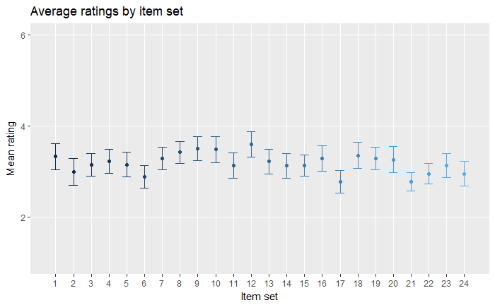

## By item set and condition

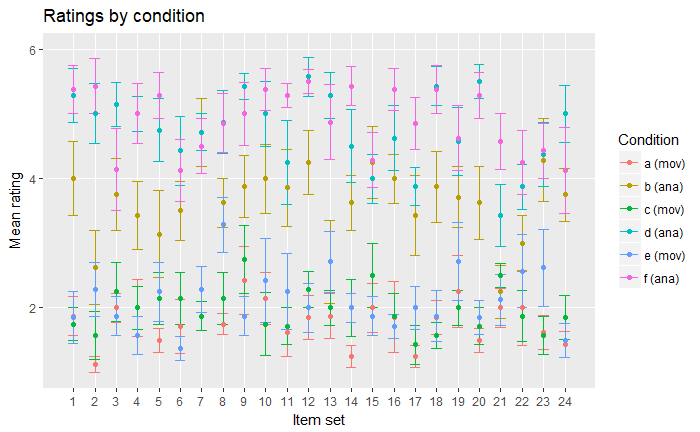

```r
# Visualize the item set summary
item_summary_w_conds %>% ggplot(aes(x = itemSet,
                                    y = mean_rating,
                                    colour = condition,
                                    group = condition,
                                    ymin = 1,
                                    ymax = 6)) -> item_plot_w_conds
item_plot_w_conds +
  labs(title = "Ratings by condition",
       x = "Item set",
       y = "Mean rating") +
  geom_errorbar(aes(ymin = mean_rating - se_rating,
                ymax = mean_rating + se_rating,
                width = 0.5)) +
  geom_point(aes(col = condition)) +
  scale_x_continuous(breaks = seq(1:24)) +
  scale_color_discrete("Condition", labels = c("a (mov)", "b (ana)", "c (mov)", "d (ana)", "e (mov)", "f (ana)")) +
  theme(panel.grid.minor = element_blank()) -> item_plot_w_conds
item_plot_w_conds
```

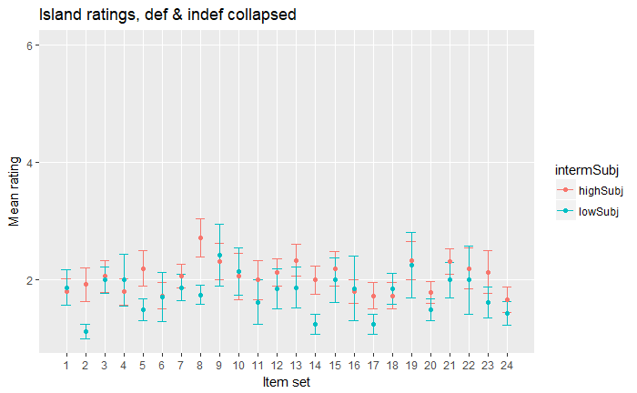

## By participant w/ def & indef collapsed

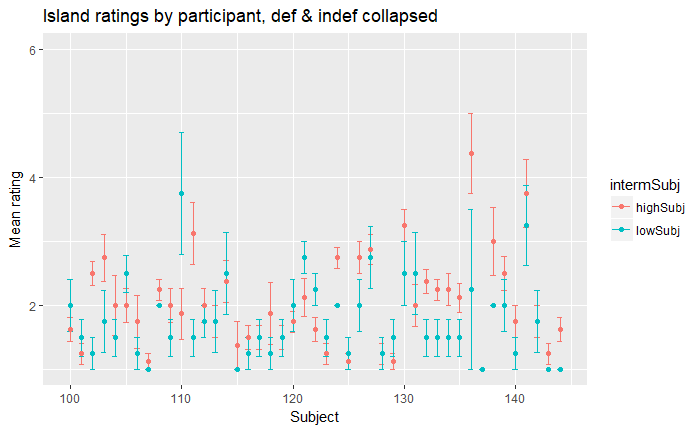

## Experimental data summary

| intermSubj | dependencyType | mean_rating | sd_rating | n | se_rating |
| --- | --- | --- | --- | --- | --- |
| def | coref | 4.888889 | 1.2185204 | 180 | 0.09082315 |
| def | move | 2.111111 | 1.1329937 | 180 | 0.08444836 |
| indef | coref | 4.738889 | 1.2388672 | 180 | 0.09233971 |
| indef | move | 1.977778 | 0.9742813 | 180 | 0.07261864 |
| there | coref | 3.633333 | 1.4489449 | 180 | 0.10799798 |
| there | move | 1.772222 | 0.9265214 | 180 | 0.06905883 |

### Data visualization

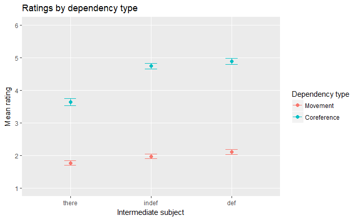

## Filler data summary and visualization

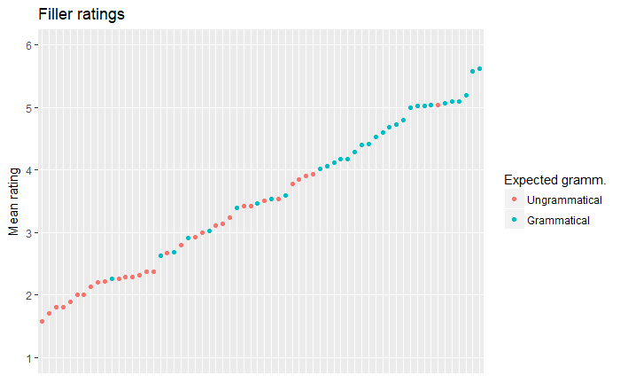

```r
# Paste rating and item ID together so that points will be ordered lowest to highest
descriptive_summary_lab_fillers$X <- paste(descriptive_summary_lab_fillers$mean_rating, descriptive_summary_lab_fillers$itemID)
# Make sure expectedGramm is a factor
descriptive_summary_lab_fillers$expectedGramm %<>% as.factor
# Make a plot for the filler items
descriptive_summary_lab_fillers %>%
  ggplot(aes(x = X,
             y = mean_rating,
             ymin = 1,
             ymax = 6,
             colour = expectedGramm,
             group = expectedGramm)) -> descriptive_plot_lab_fillers
descriptive_plot_lab_fillers +
  geom_point(aes(col = expectedGramm)) +
  labs(title = "Filler ratings",
       x = NULL,
       y = "Mean rating",
       colour = "Expected gramm.") +
  scale_y_continuous(breaks = seq(1:6)) +
  scale_color_discrete(labels = c("Ungrammatical", "Grammatical")) +
  theme(axis.text.x = element_blank(),
        axis.ticks.x = element_blank(),
        panel.grid.minor = element_blank())
```

### Juxtaposed with experimental data

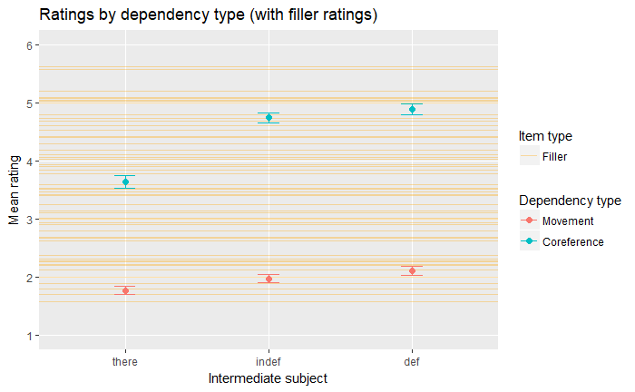

# Analysis

```r
# Check contrasts
contrasts(experiment_data_lab$intermSubj)
```

```
      indef there
def       0     0
indef     1     0
there     0     1
```

```r
# Helmert-contrast-ize
contrasts(experiment_data_lab$intermSubj) <- "contr.helmert"

# See what happened
contrasts(experiment_data_lab$intermSubj)
```

```
      [,1] [,2]
def     -1   -1
indef    1   -1
there    0    2
```

```r
# Make sure ratings data is a factor
experiment_data_lab$rating %<>% as.factor

# Set contrasts for factors
contrasts(experiment_data_lab$intermSubj)[1,] <- c(-0.5, -0.5)
contrasts(experiment_data_lab$intermSubj)[2,] <- c(0.5, -0.5)
contrasts(experiment_data_lab$intermSubj)[3,] <- c(-0.5, 0.5)
contrasts(experiment_data_lab$dependencyType) <- c(-0.5, 0.5)

# Run simple effects analysis
clm(rating ~ intermSubj * dependencyType, data = experiment_data_lab) -> clm.interm_deptype
summary(clm.interm_deptype)
```

```
formula: rating ~ intermSubj * dependencyType
data:    experiment_data_lab

 link  threshold nobs logLik   AIC     niter max.grad cond.H
 logit flexible  1080 -1516.30 3052.61 5(0)  8.55e-08 5.4e+01

Coefficients:
                            Estimate Std. Error z value Pr(>|z|)
intermSubj1                 -0.19717    0.13551  -1.455    0.146
intermSubj2                 -1.14980    0.14041  -8.189 2.64e-16 ***
dependencyType1             -3.37619    0.17068 -19.781  < 2e-16 ***
intermSubj1:dependencyType1  0.06798    0.27101   0.251    0.802
intermSubj2:dependencyType1  1.09621    0.27961   3.920 8.84e-05 ***
---
Signif. codes:  0 ‘***’ 0.001 ‘**’ 0.01 ‘*’ 0.05 ‘.’ 0.1 ‘ ’ 1

Threshold coefficients:
    Estimate Std. Error z value
1|2 -2.03839    0.10279 -19.830
2|3 -0.31733    0.08972  -3.537
3|4  0.97412    0.09501  10.253
4|5  1.92785    0.10699  18.019
5|6  2.97064    0.12472  23.818
```

Sprouse, Jon, Matt Wagers, and Colin Phillips. 2013. “Deriving competing predictions from grammatical approaches and reductionist approaches to island effects.” In *Experimental Syntax and Island Effects*, edited by Jon Sprouse and Norbert Hornstein, 21–41. Cambridge, United Kingdom: Cambridge University Press. doi:10.1017/CBO9781139035309.003.